# w6b: Residual Analysis

[Nao Mimoto](https://nmimoto.github.io/) - [Dept. of Statistics](http://www.uakron.edu/stat/) : [The University of Akron](http://www.uakron.edu)

[Class Web Page](https://nmimoto.github.io/477/)

## 1. Residual Analysis

After time series model is fit, we want to check the residual for

- Randomness (no autocorrelation)
- Conditional Heteroscedasticity (constatnt conditional variance)
- Normality (not important in ARMA)

Given residuals, $\hat \epsilon_t$, we want to see if it is an uncorrelated sequence or not.

- Plot ACF/PACF
- Ljung-Box test for randomness
- McLeod-Li test

## 2. Test for Randomness

### Ljung-Box test

With sample ACF $\hat \rho(h)$,
$$Q = n(n+2) \sum_{h=1}^H \frac{ \hat \rho(h)^2}{n-h}$$

Under the null hypothesis of uncorrelation, $Q \sim \chi^2(H)$.

Use as one-sided upper tailed test.

Parameter $H$ must be chosen by hand. Use couple of different values.

### Example: L-B test

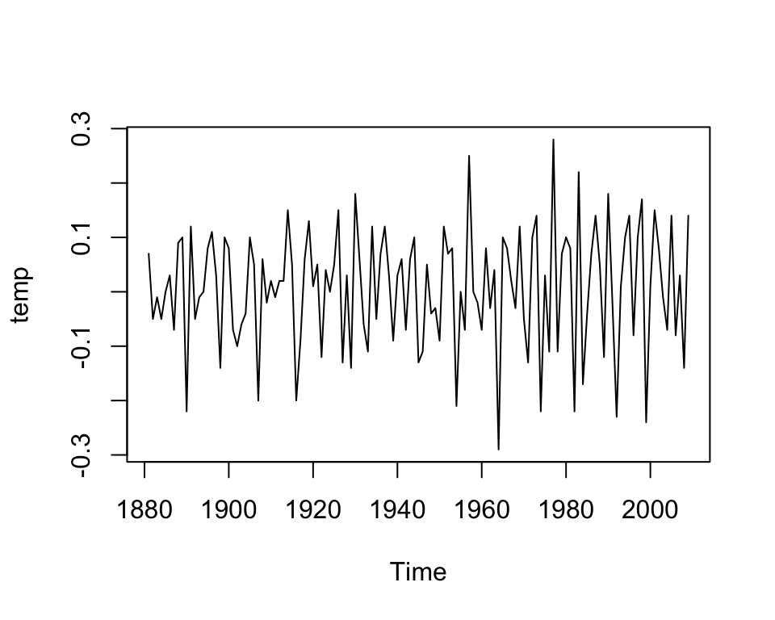

```r
  D  = read.csv("https://nmimoto.github.io/datasets/gtemp.csv")
  D1 = ts(D, start=c(1880), freq=1)
  D2 = diff(D1)

  plot(D2)
```

```r
  library(forecast)

  Fit1 = Arima(D2, order=c(2,0,0), include.mean=FALSE)

  res = Fit1$resid

  Box.test(res,   lag = 15, type = "Ljung-Box")
```

```
##
##  Box-Ljung test
##
## data:  res
## X-squared = 30.756, df = 15, p-value = 0.00947
```

```r
  Box.test(res,   lag = 20, type = "Ljung-Box")
```

```
##
##  Box-Ljung test
##
## data:  res
## X-squared = 34.615, df = 20, p-value = 0.02225
```

```r
  Box.test(res,   lag = 25, type = "Ljung-Box")
```

```
##
##  Box-Ljung test
##
## data:  res
## X-squared = 38.631, df = 25, p-value = 0.04009
```

### Example: Null Distribution of L-B test

```r
  X = rnorm(100, 2, 4)

  Box.test(res, lag=15, type="Ljung-Box")
```

```
##
##  Box-Ljung test
##
## data:  res
## X-squared = 30.756, df = 15, p-value = 0.00947
```

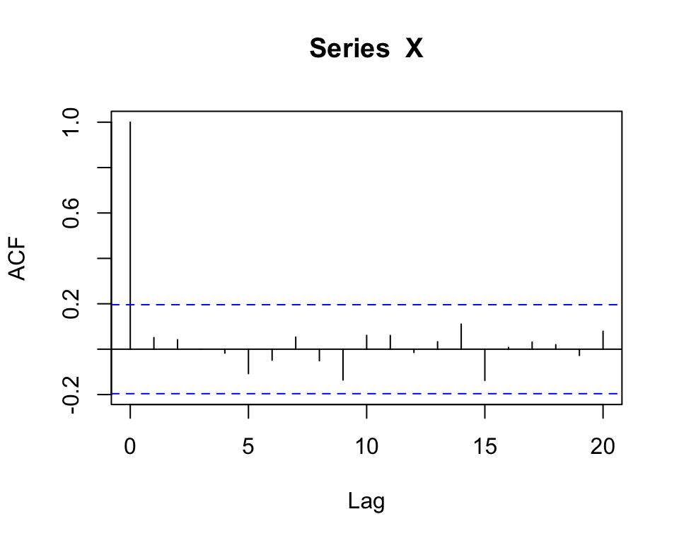

```r
  n=100
  sam.acf = acf(X)$acf
```

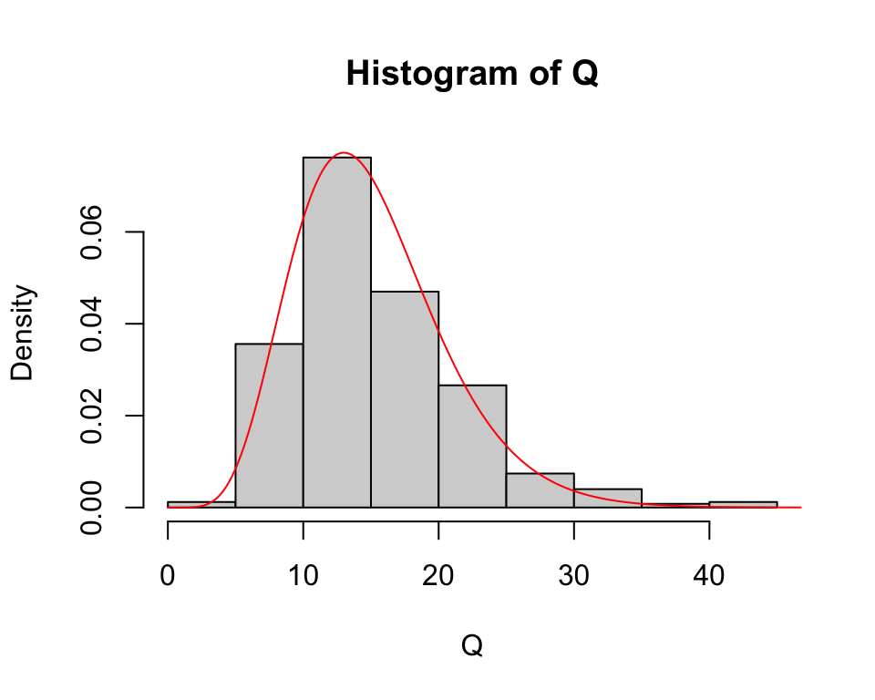

```r
  Q = n*(n+2)*sum( sam.acf[2:16]^2/(n-(1:15)) )

  Q = 0
  for (i in 1:1000) {
    X = rnorm(100, 2, 4)
    sam.acf = acf(X, plot=FALSE)$acf
    Q[i] = n*(n+2)*sum( sam.acf[2:16]^2/(n-(1:15)) )
  }

  hist(Q, freq=FALSE)
  t = seq(0, 50, .1)
  lines(t, dchisq(t, 15), col="red")
```

## 3. Test for Conditional Heteroscedasticity

### McLeod-Li test

Instead of testing $Y_t$, test $Y_t^2$ for uncorrelation.

Use same test statistic as Ljung-Box, replace $Y_t$ with $Y_t^2$.

### Ex: McLeod-Li test

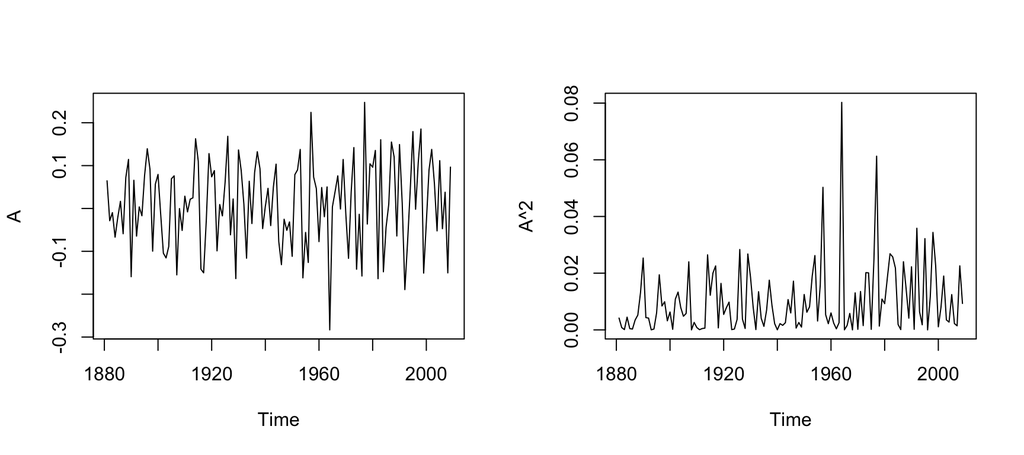

```r
  A = Fit1$resid

  layout(matrix(1:2, 1, 2))
  plot(A)
  plot(A^2)
```

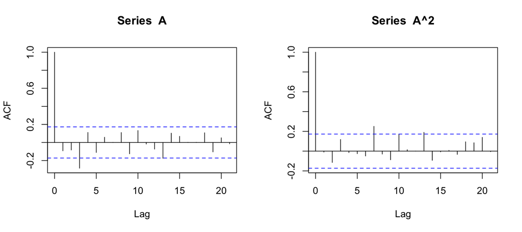

```r
  acf(A)
  acf(A^2)
```

```r
  layout(1,1,1)

  Box.test(A^2, lag = 15, type = "Ljung-Box")
```

```
##
##  Box-Ljung test
##
## data:  A^2
## X-squared = 24.777, df = 15, p-value = 0.05302
```

```r
  Box.test(A^2, lag = 20, type = "Ljung-Box")
```

```
##
##  Box-Ljung test
##
## data:  A^2
## X-squared = 30.416, df = 20, p-value = 0.06339
```

### Ex: Conditional Heteroscedasticity

```r
  library(quantmod)       # install.packages("quantmod")

  getSymbols("AAPL")
```

```
## [1] "AAPL"
```

```r
  head(AAPL)
```

```
##            AAPL.Open AAPL.High AAPL.Low AAPL.Close AAPL.Volume AAPL.Adjusted
## 2007-01-03  3.081786  3.092143 2.925000   2.992857  1238319600      2.565971
## 2007-01-04  3.001786  3.069643 2.993571   3.059286   847260400      2.622925
## 2007-01-05  3.063214  3.078571 3.014286   3.037500   834741600      2.604246
## 2007-01-08  3.070000  3.090357 3.045714   3.052500   797106800      2.617107
## 2007-01-09  3.087500  3.320714 3.041071   3.306071  3349298400      2.834510
## 2007-01-10  3.383929  3.492857 3.337500   3.464286  2952880000      2.970158
```

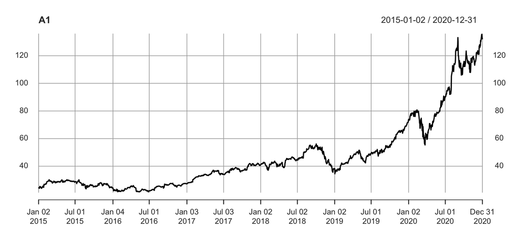

```r
  A = AAPL$AAPL.Adjusted
  A1 = A["2015::2020"]
  plot(A1)
```

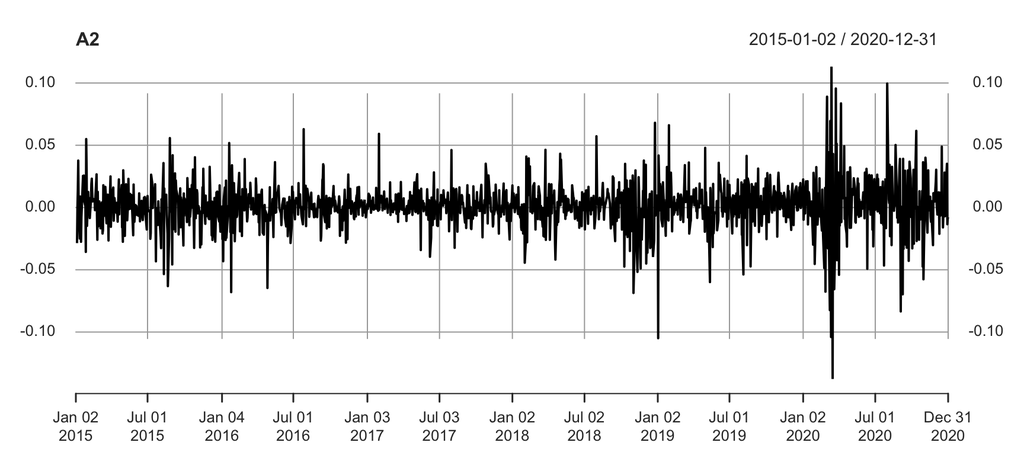

```r
  A2 = diff(log(A1))
  plot(A2)
```

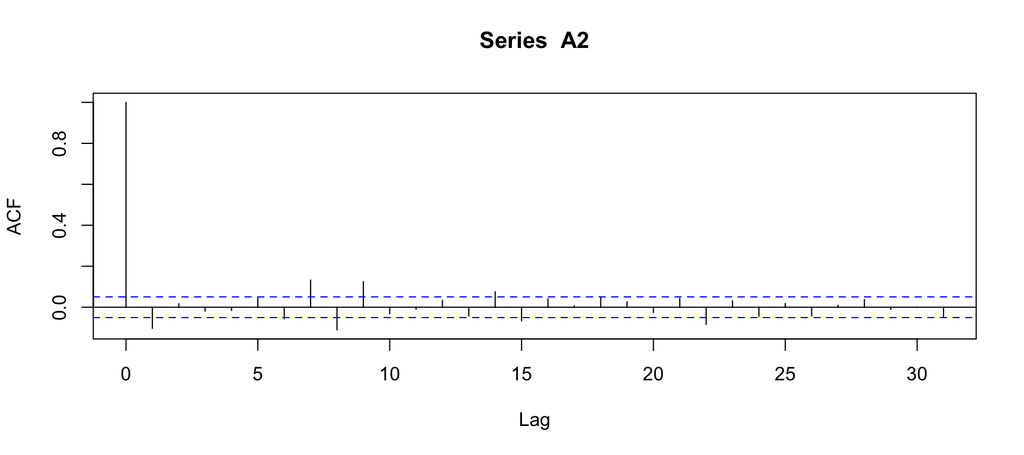

```r
  acf(A2, na.action=na.pass)
```

## 4. Test for Normality

### Test for Normality

Given sequence $Y_t$, we want to test if it came from Normal distribution. ($\mu$ and $\si$ unspecified).

q-q normal plot

Jarque-Bera test

### qq-normal plot

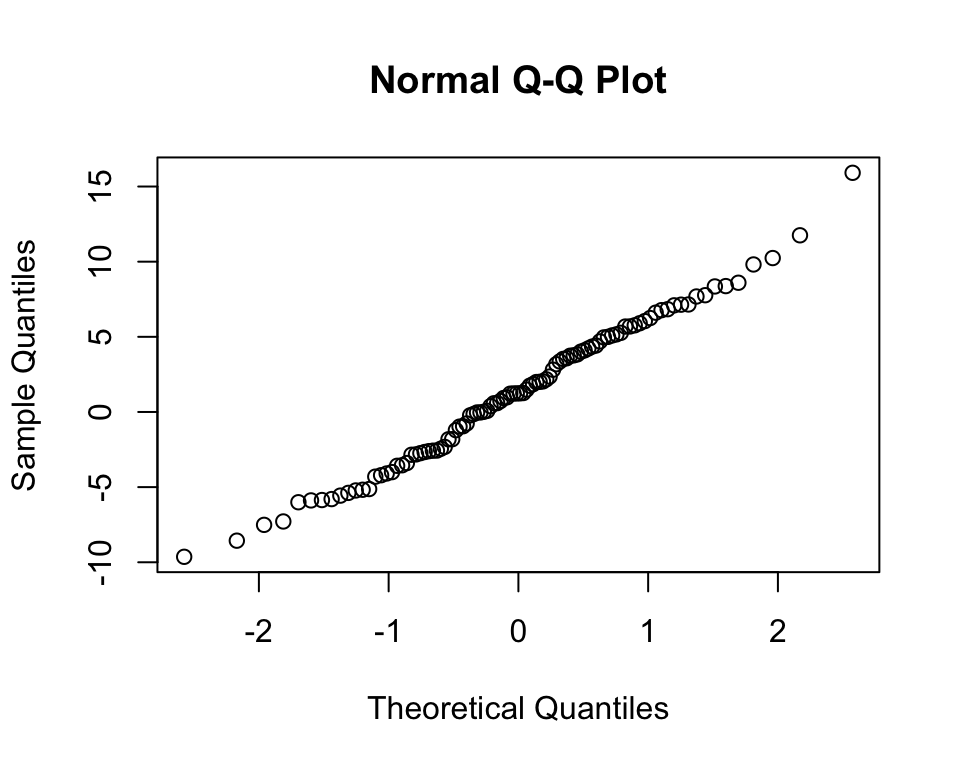

```r
  X = rnorm(100, 2, 5)
  qqnorm(X)
```

### Jarque-Bera Test for Normality

Normal distribution has skewness 0, and kurtosis of 3. for any $\mu$ and $\sigma^2$.
$$\mbox{Skewness} = \frac{E[(Y_t - \mu )^3]}{ \mbox{SD}(Y_t)^{3}}
\hspace10mm
\mbox{ Kurtosis } = \frac{E[(Y_t - \mu )^4]}{ \mbox{SD}(Y_t)^{4}}$$
$$JB = \frac{n}{6} \Big(S^2 + \frac{1}{4}(K-3)^2\Big)$$
where $S$ is sample skewness, and $K$ is sample kurtosis.

Asymptotically $JB$ has $\chi^2(2)$ distribution under the normality.

### Ex: Testing Normality

```r
  library(tseries)  # load tseries package   ( install.packge("tseries") if first time)

  # acf(res)
  # acf(res, na.action=na.pass)
```

```r
  res = Fit1$resid
  res = res[ which(is.na(res)==0) ]    # remove NA from res

  jarque.bera.test(res)
```

```
##
##  Jarque Bera Test
##
## data:  res
## X-squared = 2.0672, df = 2, p-value = 0.3557
```

## 5. Custom Functions

### Making Your Own Function in R

```r
  x = 5
  f = exp(5+4)
  f

  f = function(x){
    exp(x+4)
  }
  f(5)
```

All of above function is put into my function called **Randomness.tests()**. You can load that into R by copy and pasting the following line.

```r
  #--- This line copy and paste Basic Functions on class web page
  source("https://nmimoto.github.io/R/TS-00.txt")

  #- Use the function as below
  res = Fit1$resid

  Randomness.tests(res)
```

## Summary

- Residuals from any time-sereis analysis must be checked for:
- Randomness (for uncorrelation) - (e.g. Ljung-Box test)
- Heteroscedasticity (Randomness of squared series) - (e.g. McLeod-Li test)
- Normality - (e.g. qqplot and Jarque-Bera test)
- Below R code will load the all-in-one function (you need package installed already)

```r
  res = Fit1$resid
  source("https://nmimoto.github.io/R/TS-00.txt")

  Randomness.tests(res)

  Stationarity.tests(res)
```

- To test if the true mean is $0$ or not, we must construct CI for $\mu$, and see if $0$ is inside the CI or not.
- For autocorrelated data, variance of the sample mean is bigger than the random sample case. We must estimate the sample mean variance by summing up sample ACVF.